# Data 621 - Homework 3

Dhairav Chhatbar, Mael Illien, Salma Elshahawy

10/15/2020

# Data 621 Homework3

## Introduction

For this assignment, we were tasked with building a binary logistic regression model from a dataset containing information on crime in various neighborhoods of a major city. Given a vector of predictors, we seek to predict whether the neighborhood crime rate is above the median.

```r
data_train <- read.csv("https://raw.githubusercontent.com/salma71/Data_621/master/HW_3/crime-training-data_modified.csv", header = TRUE)
data_test <- read.csv("https://raw.githubusercontent.com/salma71/Data_621/master/HW_3/crime-evaluation-data_modified.csv", header = TRUE)
```

## Data Exploration

### Data Exploration

The dataset is composed of 466 observations and 12 predictor variables. The response variable *target* is binary (0 or 1). A quick look at the distribution of the training dataset reveals some skewed predictors. All observations in this dataset are complete.

```r
skim(data_train)
```

Data summary

| Name | data_train |
| --- | --- |
| Number of rows | 466 |
| Number of columns | 13 |
| _______________________ |  |
| Column type frequency: |  |
| numeric | 13 |
| ________________________ |  |
| Group variables | None |

**Variable type: numeric**

| skim_variable | n_missing | complete_rate | mean | sd | p0 | p25 | p50 | p75 | p100 | hist |
| --- | --- | --- | --- | --- | --- | --- | --- | --- | --- | --- |
| zn | 0 | 1 | 11.58 | 23.36 | 0.00 | 0.00 | 0.00 | 16.25 | 100.00 | ▇▁▁▁▁ |
| indus | 0 | 1 | 11.11 | 6.85 | 0.46 | 5.15 | 9.69 | 18.10 | 27.74 | ▇▆▁▇▁ |
| chas | 0 | 1 | 0.07 | 0.26 | 0.00 | 0.00 | 0.00 | 0.00 | 1.00 | ▇▁▁▁▁ |
| nox | 0 | 1 | 0.55 | 0.12 | 0.39 | 0.45 | 0.54 | 0.62 | 0.87 | ▇▇▅▃▁ |
| rm | 0 | 1 | 6.29 | 0.70 | 3.86 | 5.89 | 6.21 | 6.63 | 8.78 | ▁▂▇▂▁ |
| age | 0 | 1 | 68.37 | 28.32 | 2.90 | 43.88 | 77.15 | 94.10 | 100.00 | ▂▂▂▃▇ |
| dis | 0 | 1 | 3.80 | 2.11 | 1.13 | 2.10 | 3.19 | 5.21 | 12.13 | ▇▅▂▁▁ |
| rad | 0 | 1 | 9.53 | 8.69 | 1.00 | 4.00 | 5.00 | 24.00 | 24.00 | ▇▂▁▁▃ |
| tax | 0 | 1 | 409.50 | 167.90 | 187.00 | 281.00 | 334.50 | 666.00 | 711.00 | ▇▇▅▁▇ |
| ptratio | 0 | 1 | 18.40 | 2.20 | 12.60 | 16.90 | 18.90 | 20.20 | 22.00 | ▁▃▅▅▇ |
| lstat | 0 | 1 | 12.63 | 7.10 | 1.73 | 7.04 | 11.35 | 16.93 | 37.97 | ▇▇▅▂▁ |
| medv | 0 | 1 | 22.59 | 9.24 | 5.00 | 17.02 | 21.20 | 25.00 | 50.00 | ▂▇▅▁▁ |
| target | 0 | 1 | 0.49 | 0.50 | 0.00 | 0.00 | 0.00 | 1.00 | 1.00 | ▇▁▁▁▇ |

### Visualization

With a closer look at the distribution of the data using density plots, we can identify bimodal distribution for *indus*, *rar* and *tax* and skew in *dis*, *nox*, *ptratio* and *zn*.

Looking at the density and box plots of each we can observe that:

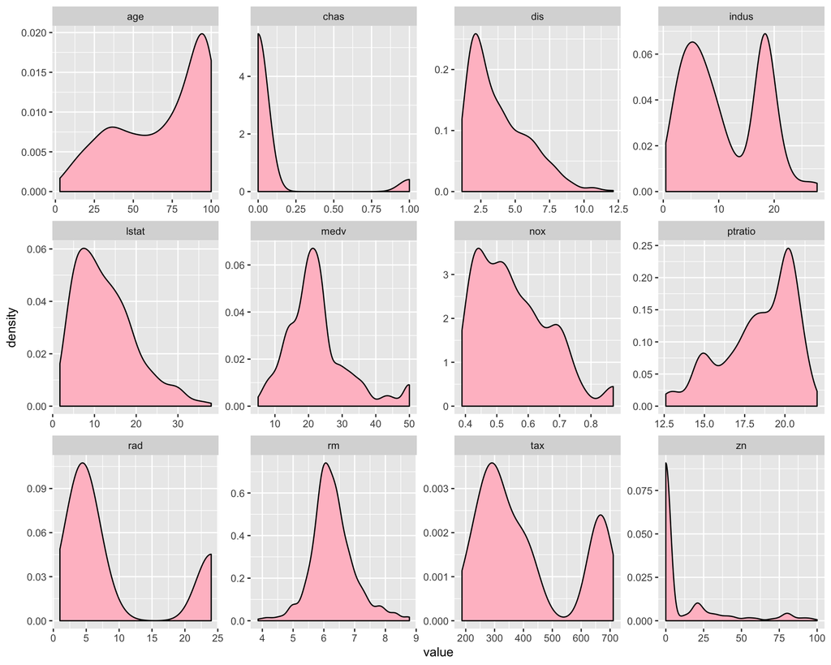

```r
data_train %>%
  select(-target) %>%
  gather() %>%
  ggplot(aes(x= value)) +
  geom_density(fill='pink') +
  facet_wrap(~key, scales = 'free')
```

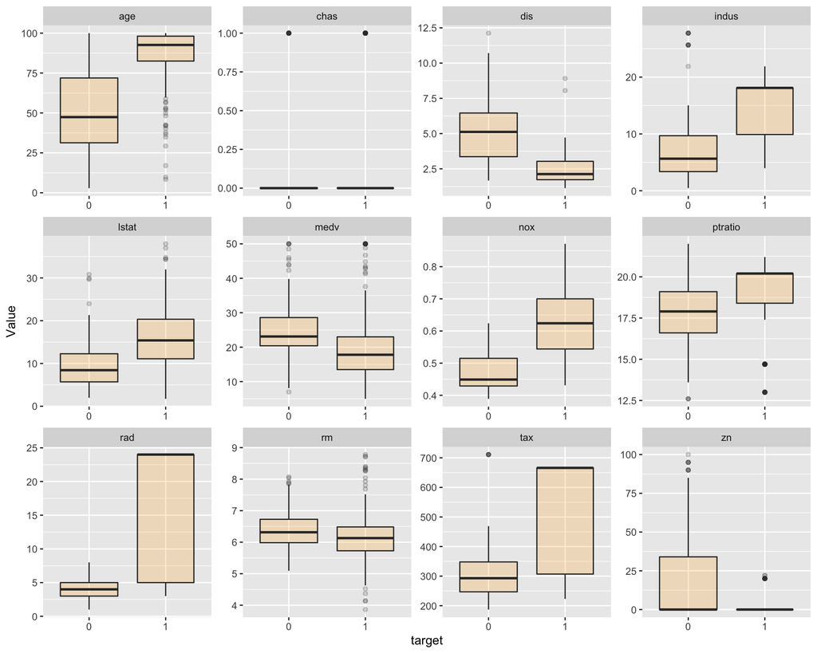

```r
data_train_long <- gather(data_train, "Variable", "Value", zn:medv)
data_train_long$target <- as.factor(data_train_long$target)
ggplot(data_train_long, aes(x=target, y=Value)) + geom_boxplot(varwidth = TRUE, alpha=0.2, fill="orange1") + facet_wrap(~Variable, scales = "free")
```

#### Correlations with Response Variable

Looking at the correlation plot of our data set we see the below and confirm some of the observations made from the density and box plots:

- the target variable is positively correlated with *nox(.73), age(.63), rad(.63)*, and *tax(.61)*
- the target variable is negatively correlated with *dis(-.62)* as seen in the density and box plots, the *chas* variable as a very weak correlation with all the other variables, and including the target. Therefore we can look to eliminate it from the analysis
- there is present a amount of correlation amongst the predictor variables and this is suspect for multicollinearity issues

Highest correlations amongst predictor variables:  
- tax|rad (.91)  
-nox|indus (.76)  
-age|nox(.74)  
-tax|indus (.73)  
-medv|rm (.71)  
-dis|indus (-.7)  
-medv|lstat (-.74)  
-dist|age (-.75)  
-dis|nox (-.77)

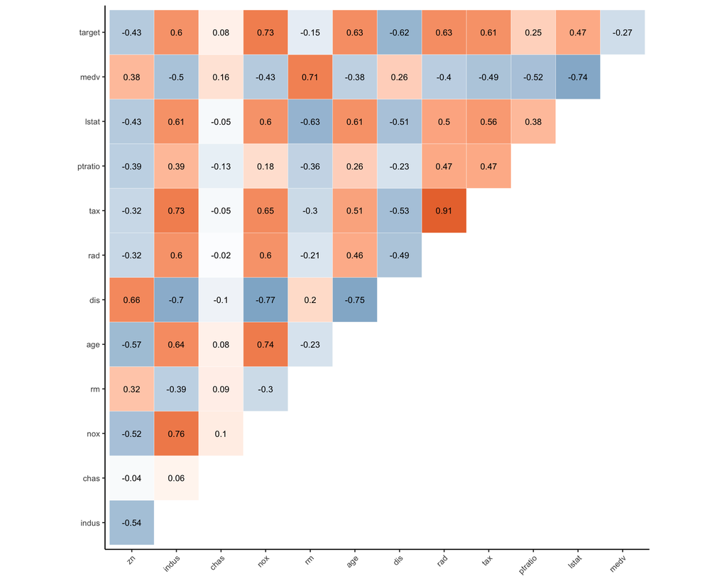

```r
q <- cor(data_train)
ggcorrplot(q, type = "upper", outline.color = "white",
           ggtheme = theme_classic,
           colors = c("#6D9EC1", "white", "#E46726"),
           lab = TRUE, show.legend = FALSE, tl.cex = 8, lab_size = 3)
```

```r
#pairs(data_train, col=data_train$target)
```

## Data Preparation

In preparation of the data to use in the model we remove the chas variable is it does not seem to have any impact on target and is not highly correlated with any other predictor variable.

We also convert the target variable into a factor from an integer type

```r
data_train_m2 <- data_train %>% select(-chas)
#convert target to factor
data_train_m2$target <- as.factor(data_train_m2$target)
```

### Influential Leverage Points

In preparation of the data to use in the model we will look to see if within the data set that are any influence points that may have a significant impact on the model.

From the general model below are some outlier observations based on Cooks distance, though not all outlier observations are influential

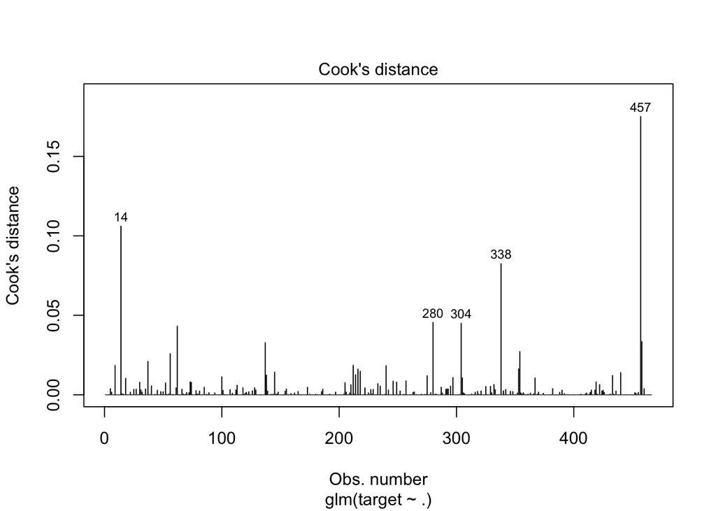

```r
ilp <- glm(target ~ .,data = data_train_m2, family = binomial(link="logit"))
#Top 5 outliers
plot(ilp, which = 4, id.n = 5)
```

To see if any outlier observations are influential we plot the standardized residual error to determine if any residuals are above the absolute value of 3.

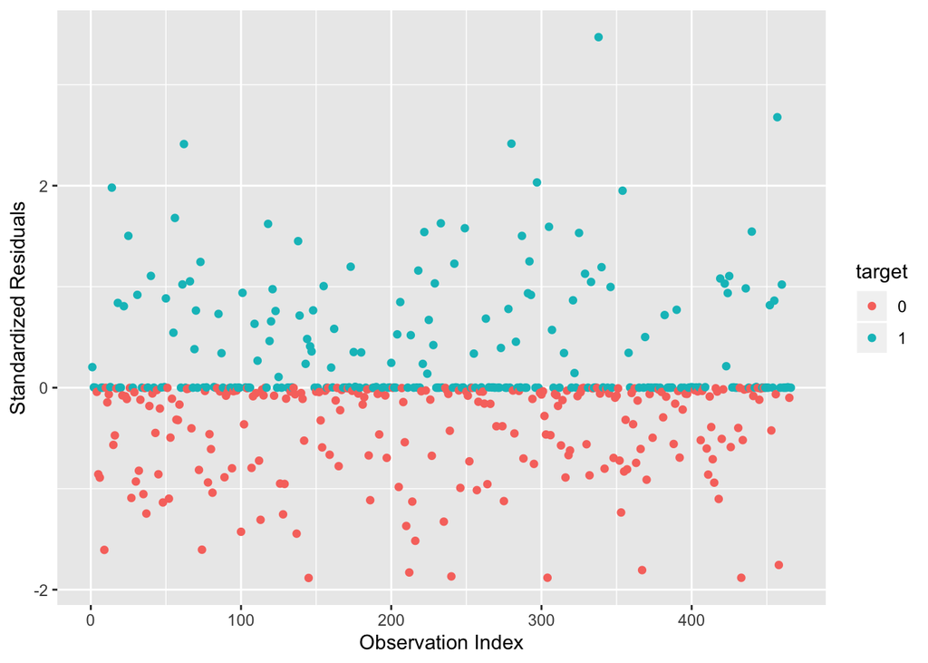

```r
augment(ilp) %>% mutate(index = 1:n()) %>% ggplot(aes(index, .std.resid)) + geom_point(aes(color=target)) + labs(y= "Standardized Residuals", x="Observation Index")
```

```r
(augment(ilp) %>% mutate(index = 1:n()) %>% top_n(2, .std.resid))[,c(1:9,15,19)]
```

| target | zn | indus | nox | rm | age | dis | rad | tax | .std.resid | index |
| --- | --- | --- | --- | --- | --- | --- | --- | --- | --- | --- |
| 1 | 20 | 6.96 | 0.464 | 5.856 | 42.1 | 4.4290 | 3 | 223 | 3.470938 | 338 |
| 1 | 0 | 10.59 | 0.489 | 5.412 | 9.8 | 3.5875 | 4 | 277 | 2.678073 | 457 |

```r
#remove from model
data_train_m2 <- data_train_m2[-c(457,338),]
```

## Model Building

Models in this sections are simply subsets of the full model.

```r
# Initialize a df that will store the metrics of models
models.df <- tibble(id=character(), formula=character(), res.deviance=numeric(), null.deviance=numeric(),
                 aic=numeric(), accuracy=numeric(), sensitivity=numeric(), specificity=numeric(),
                precision.deviance=numeric(), stringsAsFactors=FALSE)
```

```r
# A function to extract the relevant metrics from the summary and confusion matrix
build_model <- function(id, formula, data) {
  glm.fit <- glm(formula, data=data, family=binomial)
  print(summary(glm.fit))
  glm.probs <- predict(glm.fit, type="response")
  # Confirm the 0.5 threshold
  glm.pred <- ifelse(glm.probs > 0.5, 1, 0)
  results <- tibble(target=data$target, pred=glm.pred)
  results <- results %>%
    mutate(pred.class = as.factor(pred), target.class = as.factor(target))

  #print(confusionMatrix(results$pred.class,results$target.class, positive = "1"))

  acc <- confusionMatrix(results$pred.class,results$target.class, positive = "1")$overall['Accuracy']
  sens <- confusionMatrix(results$pred.class,results$target.class, positive = "1")$byClass['Sensitivity']
  spec <- confusionMatrix(results$pred.class,results$target.class, positive = "1")$byClass['Specificity']
  prec <- confusionMatrix(results$pred.class,results$target.class, positive = "1")$byClass['Precision']
  res.deviance <- glm.fit$deviance
  null.deviance <- glm.fit$null.deviance
  aic <- glm.fit$aic
  metrics <- list(res.deviance=res.deviance, null.deviance=null.deviance,aic=aic, accuracy=acc, sensitivity=sens, specificity=spec, precision=prec)
  metrics <- lapply(metrics, round, 3)

  plot(roc(results$target.class,glm.probs), print.auc = TRUE)
  model.df <- tibble(id=id, formula=formula, res.deviance=metrics$res.deviance, null.deviance=metrics$null.deviance,
                         aic=metrics$aic, accuracy=metrics$accuracy, sensitivity=metrics$sensitivity, specificity=metrics$specificity, precision=metrics$precision)
  model.list <- list(model=glm.fit, df_info=model.df)
  return(model.list)
}
```

### Model 1: Base Model Subsets

Model 1 starts with a complete model including all predictors iteratively finds the model with the subset of predictors that are statistically significant.

```r
m1 <- build_model('m1', "target ~ .", data = data_train)
```

```
Call:
glm(formula = formula, family = binomial, data = data)

Deviance Residuals:
    Min       1Q   Median       3Q      Max
-1.8464  -0.1445  -0.0017   0.0029   3.4665

Coefficients:
              Estimate Std. Error z value Pr(>|z|)
(Intercept) -40.822934   6.632913  -6.155 7.53e-10 ***
zn           -0.065946   0.034656  -1.903  0.05706 .
indus        -0.064614   0.047622  -1.357  0.17485
chas          0.910765   0.755546   1.205  0.22803
nox          49.122297   7.931706   6.193 5.90e-10 ***
rm           -0.587488   0.722847  -0.813  0.41637
age           0.034189   0.013814   2.475  0.01333 *
dis           0.738660   0.230275   3.208  0.00134 **
rad           0.666366   0.163152   4.084 4.42e-05 ***
tax          -0.006171   0.002955  -2.089  0.03674 *
ptratio       0.402566   0.126627   3.179  0.00148 **
lstat         0.045869   0.054049   0.849  0.39608
medv          0.180824   0.068294   2.648  0.00810 **
---
Signif. codes:  0 '***' 0.001 '**' 0.01 '*' 0.05 '.' 0.1 ' ' 1

(Dispersion parameter for binomial family taken to be 1)

    Null deviance: 645.88  on 465  degrees of freedom
Residual deviance: 192.05  on 453  degrees of freedom
AIC: 218.05

Number of Fisher Scoring iterations: 9
```

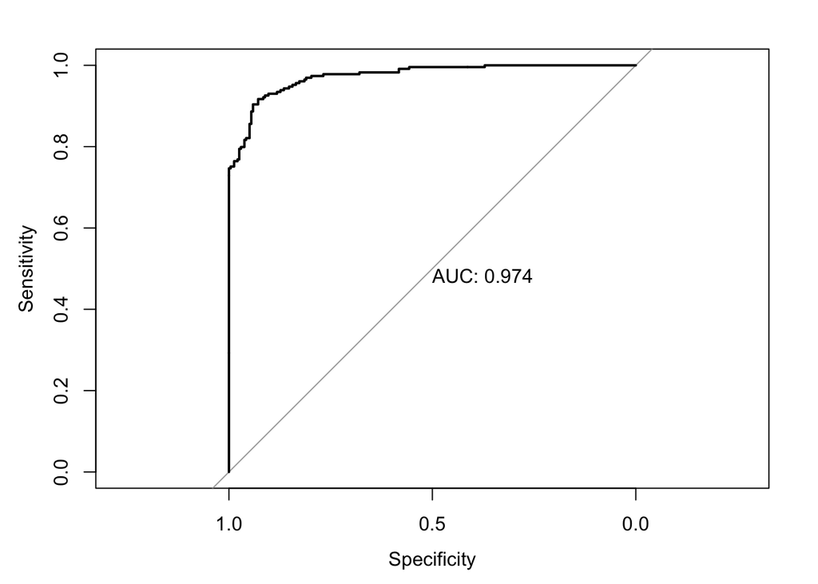

```r
m1$df_info
```

| id | formula | res.deviance | null.deviance | aic | accuracy | sensitivity | specificity | precision |
| --- | --- | --- | --- | --- | --- | --- | --- | --- |
| m1 | target ~ . | 192.047 | 645.876 | 218.047 | 0.916 | 0.904 | 0.928 | 0.924 |

```r
models.df <- rbind(models.df,m1$df_info)
```

```r
m1_b <- build_model('m1_b', "target ~ . -rm", data = data_train)
```

```
Call:
glm(formula = formula, family = binomial, data = data)

Deviance Residuals:
    Min       1Q   Median       3Q      Max
-1.8750  -0.1679  -0.0019   0.0032   3.4391

Coefficients:
              Estimate Std. Error z value Pr(>|z|)
(Intercept) -41.649437   6.503781  -6.404 1.51e-10 ***
zn           -0.068448   0.034414  -1.989 0.046707 *
indus        -0.063406   0.047493  -1.335 0.181854
chas          0.931110   0.757531   1.229 0.219020
nox          48.092158   7.728183   6.223 4.88e-10 ***
age           0.028384   0.011619   2.443 0.014568 *
dis           0.691454   0.218298   3.167 0.001538 **
rad           0.643883   0.159204   4.044 5.25e-05 ***
tax          -0.006310   0.002932  -2.152 0.031399 *
ptratio       0.361822   0.113913   3.176 0.001492 **
lstat         0.062518   0.049592   1.261 0.207437
medv          0.137881   0.041423   3.329 0.000873 ***
---
Signif. codes:  0 '***' 0.001 '**' 0.01 '*' 0.05 '.' 0.1 ' ' 1

(Dispersion parameter for binomial family taken to be 1)

    Null deviance: 645.88  on 465  degrees of freedom
Residual deviance: 192.71  on 454  degrees of freedom
AIC: 216.71

Number of Fisher Scoring iterations: 9
```

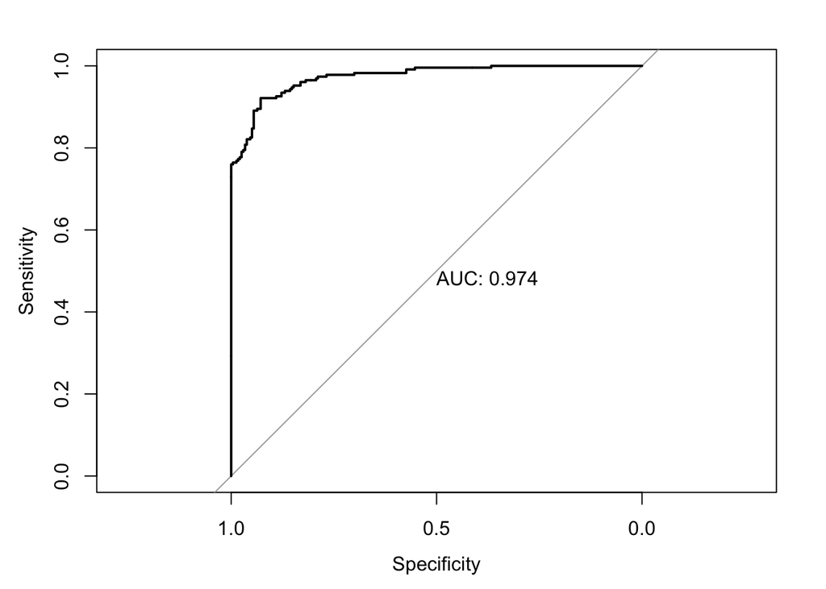

```r
m1_b$df_info
```

| id | formula | res.deviance | null.deviance | aic | accuracy | sensitivity | specificity | precision |
| --- | --- | --- | --- | --- | --- | --- | --- | --- |
| m1_b | target ~ . -rm | 192.711 | 645.876 | 216.711 | 0.916 | 0.904 | 0.928 | 0.924 |

```r
models.df <- rbind(models.df,m1_b$df_info)
```

```r
m1_c <- build_model('m1_c', "target ~ . -rm - chas", data = data_train)
```

```
Call:
glm(formula = formula, family = binomial, data = data)

Deviance Residuals:
    Min       1Q   Median       3Q      Max
-1.8779  -0.1646  -0.0015   0.0030   3.4366

Coefficients:
              Estimate Std. Error z value Pr(>|z|)
(Intercept) -40.271093   6.335539  -6.356 2.07e-10 ***
zn           -0.074693   0.034472  -2.167 0.030252 *
indus        -0.050727   0.045716  -1.110 0.267166
nox          46.245279   7.498336   6.167 6.94e-10 ***
age           0.028882   0.011572   2.496 0.012564 *
dis           0.666663   0.215818   3.089 0.002008 **
rad           0.691985   0.156587   4.419 9.91e-06 ***
tax          -0.007032   0.002876  -2.445 0.014490 *
ptratio       0.335525   0.110981   3.023 0.002501 **
lstat         0.070234   0.049073   1.431 0.152367
medv          0.138750   0.041554   3.339 0.000841 ***
---
Signif. codes:  0 '***' 0.001 '**' 0.01 '*' 0.05 '.' 0.1 ' ' 1

(Dispersion parameter for binomial family taken to be 1)

    Null deviance: 645.88  on 465  degrees of freedom
Residual deviance: 194.24  on 455  degrees of freedom
AIC: 216.24

Number of Fisher Scoring iterations: 9
```

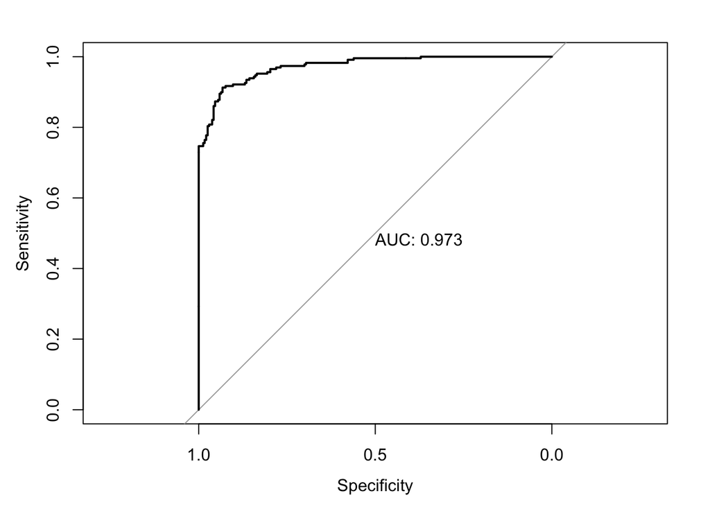

```r
m1_c$df_info
```

| id | formula | res.deviance | null.deviance | aic | accuracy | sensitivity | specificity | precision |
| --- | --- | --- | --- | --- | --- | --- | --- | --- |
| m1_c | target ~ . -rm - chas | 194.244 | 645.876 | 216.244 | 0.923 | 0.913 | 0.932 | 0.929 |

```r
models.df <- rbind(models.df,m1_c$df_info)
```

```r
m1_d <- build_model('m1_d', "target ~ . -rm -chas -indus", data = data_train)
```

```
Call:
glm(formula = formula, family = binomial, data = data)

Deviance Residuals:
    Min       1Q   Median       3Q      Max
-1.9279  -0.1640  -0.0016   0.0027   3.3989

Coefficients:
              Estimate Std. Error z value Pr(>|z|)
(Intercept) -38.786168   6.161170  -6.295 3.07e-10 ***
zn           -0.072933   0.033022  -2.209 0.027199 *
nox          43.014846   6.689945   6.430 1.28e-10 ***
age           0.028379   0.011401   2.489 0.012809 *
dis           0.658786   0.214787   3.067 0.002161 **
rad           0.739415   0.152375   4.853 1.22e-06 ***
tax          -0.008045   0.002651  -3.035 0.002408 **
ptratio       0.334196   0.111780   2.990 0.002792 **
lstat         0.064814   0.048427   1.338 0.180769
medv          0.138257   0.041630   3.321 0.000897 ***
---
Signif. codes:  0 '***' 0.001 '**' 0.01 '*' 0.05 '.' 0.1 ' ' 1

(Dispersion parameter for binomial family taken to be 1)

    Null deviance: 645.88  on 465  degrees of freedom
Residual deviance: 195.51  on 456  degrees of freedom
AIC: 215.51

Number of Fisher Scoring iterations: 9
```

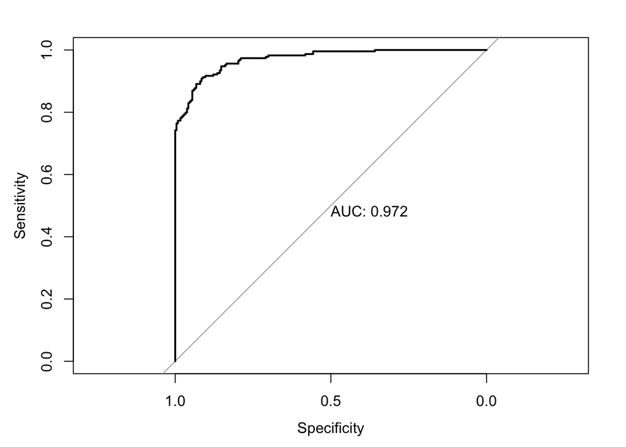

```r
m1_d$df_info
```

| id | formula | res.deviance | null.deviance | aic | accuracy | sensitivity | specificity | precision |
| --- | --- | --- | --- | --- | --- | --- | --- | --- |
| m1_d | target ~ . -rm -chas -indus | 195.515 | 645.876 | 215.515 | 0.912 | 0.908 | 0.916 | 0.912 |

```r
models.df <- rbind(models.df,m1_d$df_info)
```

```r
m1_e <- build_model('m1_e', "target ~ . -rm -chas -indus -lstat", data = data_train)
```

```
Call:
glm(formula = formula, family = binomial, data = data)

Deviance Residuals:
    Min       1Q   Median       3Q      Max
-1.8295  -0.1752  -0.0021   0.0032   3.4191

Coefficients:
              Estimate Std. Error z value Pr(>|z|)
(Intercept) -37.415922   6.035013  -6.200 5.65e-10 ***
zn           -0.068648   0.032019  -2.144  0.03203 *
nox          42.807768   6.678692   6.410 1.46e-10 ***
age           0.032950   0.010951   3.009  0.00262 **
dis           0.654896   0.214050   3.060  0.00222 **
rad           0.725109   0.149788   4.841 1.29e-06 ***
tax          -0.007756   0.002653  -2.924  0.00346 **
ptratio       0.323628   0.111390   2.905  0.00367 **
medv          0.110472   0.035445   3.117  0.00183 **
---
Signif. codes:  0 '***' 0.001 '**' 0.01 '*' 0.05 '.' 0.1 ' ' 1

(Dispersion parameter for binomial family taken to be 1)

    Null deviance: 645.88  on 465  degrees of freedom
Residual deviance: 197.32  on 457  degrees of freedom
AIC: 215.32

Number of Fisher Scoring iterations: 9
```

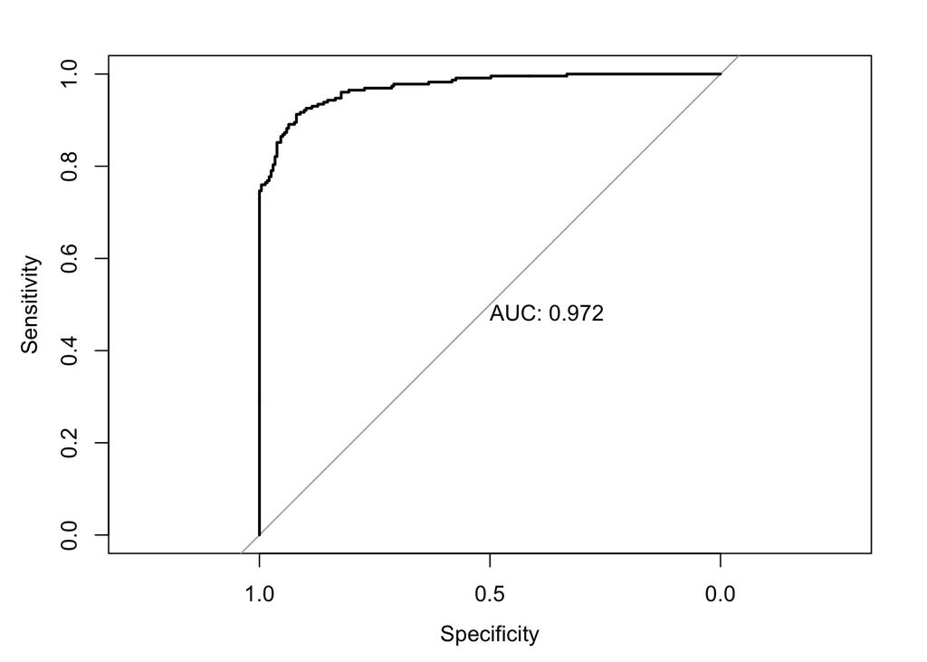

```r
m1_e$df_info
```

| id | formula | res.deviance | null.deviance | aic | accuracy | sensitivity | specificity | precision |
| --- | --- | --- | --- | --- | --- | --- | --- | --- |
| m1_e | target ~ . -rm -chas -indus -lstat | 197.323 | 645.876 | 215.323 | 0.912 | 0.904 | 0.92 | 0.916 |

```r
models.df <- rbind(models.df,m1_e$df_info)
```

Here is a summary of the models built in this section.

```r
models.df
```

| id | formula | res.deviance | null.deviance | aic | accuracy | sensitivity | specificity | precision |
| --- | --- | --- | --- | --- | --- | --- | --- | --- |
| m1 | target ~ . | 192.047 | 645.876 | 218.047 | 0.916 | 0.904 | 0.928 | 0.924 |
| m1_b | target ~ . -rm | 192.711 | 645.876 | 216.711 | 0.916 | 0.904 | 0.928 | 0.924 |
| m1_c | target ~ . -rm - chas | 194.244 | 645.876 | 216.244 | 0.923 | 0.913 | 0.932 | 0.929 |
| m1_d | target ~ . -rm -chas -indus | 195.515 | 645.876 | 215.515 | 0.912 | 0.908 | 0.916 | 0.912 |
| m1_e | target ~ . -rm -chas -indus -lstat | 197.323 | 645.876 | 215.323 | 0.912 | 0.904 | 0.920 | 0.916 |

### Model 2: Observation Removal

Model 2 is a model that has the below characteristics:

- Predictor chas as been removed
- The target variable has been converted to a factor
- Observations 338 and 457 have been removed as influencial outliers
- In the above sections we indicated that we were concerned with multicollinearity issues with the predictor values. We look further into this by checking the Variance Inflation Factor (VIF), where anything above a 5 is a high collinearity that may be problematic to the model. We see that the predictor medv has a VIF value of 9.

```r
m2 <- build_model("m2", "target ~ .", data = data_train_m2)
```

```
Call:
glm(formula = formula, family = binomial, data = data)

Deviance Residuals:
     Min        1Q    Median        3Q       Max
-1.91120  -0.07794  -0.00019   0.00068   2.83800

Coefficients:
              Estimate Std. Error z value Pr(>|z|)
(Intercept) -48.713108   7.885103  -6.178 6.50e-10 ***
zn           -0.101575   0.041487  -2.448 0.014352 *
indus        -0.070315   0.050020  -1.406 0.159802
nox          58.567669   9.306145   6.293 3.11e-10 ***
rm           -1.059071   0.803827  -1.318 0.187659
age           0.061760   0.016582   3.725 0.000196 ***
dis           1.056492   0.274292   3.852 0.000117 ***
rad           0.865495   0.181865   4.759 1.95e-06 ***
tax          -0.007048   0.003184  -2.214 0.026856 *
ptratio       0.483564   0.141717   3.412 0.000644 ***
lstat        -0.015129   0.056362  -0.268 0.788376
medv          0.235034   0.078814   2.982 0.002862 **
---
Signif. codes:  0 '***' 0.001 '**' 0.01 '*' 0.05 '.' 0.1 ' ' 1

(Dispersion parameter for binomial family taken to be 1)

    Null deviance: 643.03  on 463  degrees of freedom
Residual deviance: 169.95  on 452  degrees of freedom
AIC: 193.95

Number of Fisher Scoring iterations: 9
```

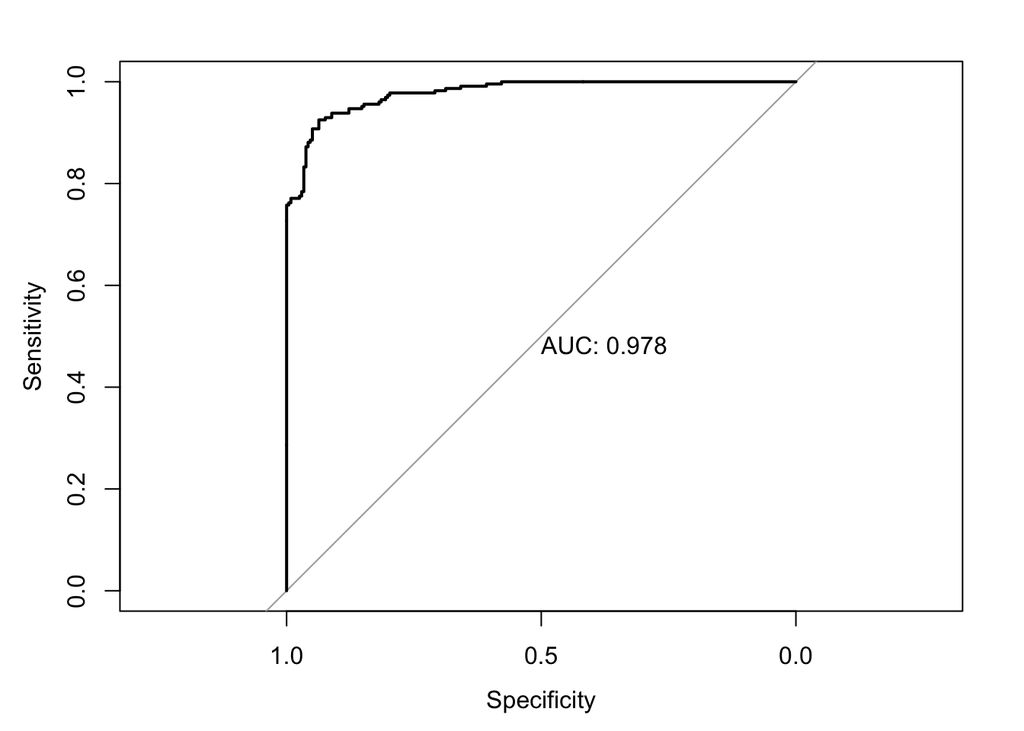

```r
m2$df_info
```

| id | formula | res.deviance | null.deviance | aic | accuracy | sensitivity | specificity | precision |
| --- | --- | --- | --- | --- | --- | --- | --- | --- |
| m2 | target ~ . | 169.95 | 643.025 | 193.95 | 0.927 | 0.916 | 0.937 | 0.933 |

```r
models.df <- rbind(models.df,m2$df_info)
```

```r
car::vif(m2$model)
```

```
      zn    indus      nox       rm      age      dis      rad      tax
2.004175 2.496646 4.715557 5.641760 3.043744 4.789220 2.071828 2.075384
 ptratio    lstat     medv
2.574732 2.459107 8.961585
```

The above model indicates that the predictor mdev can be problematic. mdev is highly correlated with lstat and rm, both of which are not significant in the model, but mdev is significant. When removing lstat and rm from the model we see that this addresses the collinearity issue with all VIF values under 5

```r
#remove rm and lstat from model
m2_b <- build_model('m2_b', "target ~ . -rm - lstat", data = data_train_m2)
```

```
Call:
glm(formula = formula, family = binomial, data = data)

Deviance Residuals:
     Min        1Q    Median        3Q       Max
-1.91283  -0.09883  -0.00026   0.00102   2.90788

Coefficients:
              Estimate Std. Error z value Pr(>|z|)
(Intercept) -49.291862   7.725211  -6.381 1.76e-10 ***
zn           -0.102530   0.040852  -2.510 0.012080 *
indus        -0.066558   0.049644  -1.341 0.180015
nox          55.998677   8.903666   6.289 3.19e-10 ***
age           0.051060   0.012897   3.959 7.52e-05 ***
dis           0.953861   0.252702   3.775 0.000160 ***
rad           0.818482   0.175225   4.671 3.00e-06 ***
tax          -0.007207   0.003166  -2.276 0.022836 *
ptratio       0.405181   0.123433   3.283 0.001029 **
medv          0.149231   0.041416   3.603 0.000314 ***
---
Signif. codes:  0 '***' 0.001 '**' 0.01 '*' 0.05 '.' 0.1 ' ' 1

(Dispersion parameter for binomial family taken to be 1)

    Null deviance: 643.03  on 463  degrees of freedom
Residual deviance: 171.78  on 454  degrees of freedom
AIC: 191.78

Number of Fisher Scoring iterations: 9
```

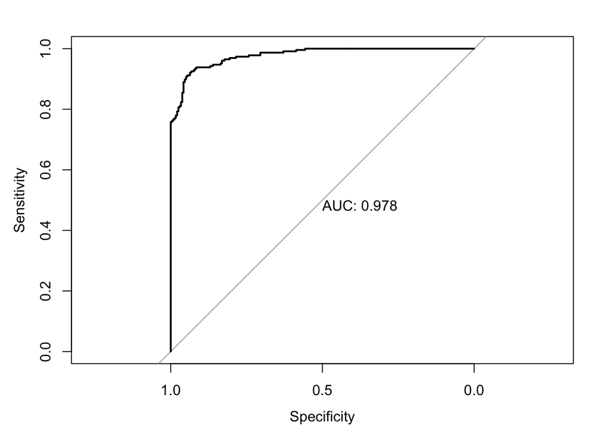

```r
m2_b$df_info
```

| id | formula | res.deviance | null.deviance | aic | accuracy | sensitivity | specificity | precision |
| --- | --- | --- | --- | --- | --- | --- | --- | --- |
| m2_b | target ~ . -rm - lstat | 171.78 | 643.025 | 191.78 | 0.927 | 0.916 | 0.937 | 0.933 |

```r
models.df <- rbind(models.df,m2_b$df_info)

car::vif(m2_b$model)
```

```
      zn    indus      nox      age      dis      rad      tax  ptratio
1.932216 2.461747 4.305506 1.906550 4.100342 1.928789 2.030718 1.994571
    medv
2.466408
```

Backward elimination produces the final model:

```r
#continue backwards elimination
#m1c <- build_model('m1c', "target ~ . -indus", data = data_train_mv2)
m2_c <- build_model('m2_c', "target ~ . -rm -lstat -indus", data = data_train_m2)
```

```
Call:
glm(formula = formula, family = binomial, data = data)

Deviance Residuals:
     Min        1Q    Median        3Q       Max
-1.92152  -0.11310  -0.00030   0.00076   2.90631

Coefficients:
              Estimate Std. Error z value Pr(>|z|)
(Intercept) -47.265354   7.511377  -6.293 3.12e-10 ***
zn           -0.099818   0.038990  -2.560 0.010465 *
nox          51.545583   8.013193   6.433 1.25e-10 ***
age           0.049284   0.012664   3.892 9.96e-05 ***
dis           0.938995   0.250466   3.749 0.000178 ***
rad           0.877730   0.171836   5.108 3.26e-07 ***
tax          -0.008424   0.002841  -2.965 0.003029 **
ptratio       0.402108   0.124753   3.223 0.001267 **
medv          0.151465   0.041492   3.650 0.000262 ***
---
Signif. codes:  0 '***' 0.001 '**' 0.01 '*' 0.05 '.' 0.1 ' ' 1

(Dispersion parameter for binomial family taken to be 1)

    Null deviance: 643.03  on 463  degrees of freedom
Residual deviance: 173.70  on 455  degrees of freedom
AIC: 191.7

Number of Fisher Scoring iterations: 9
```

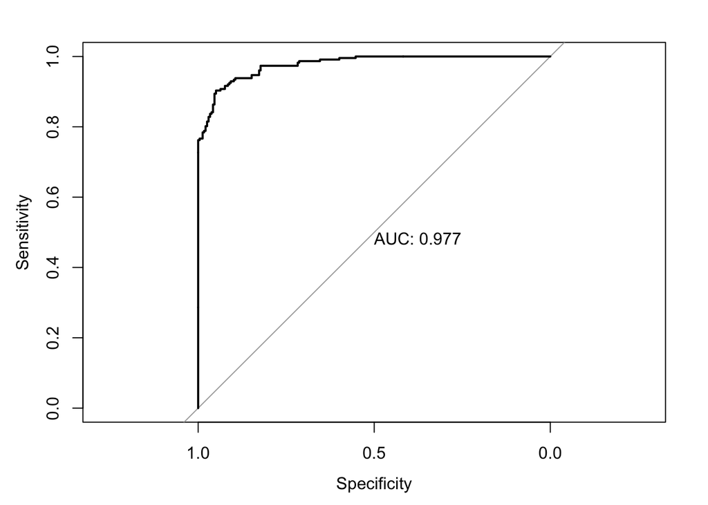

```r
m2_c$df_info
```

| id | formula | res.deviance | null.deviance | aic | accuracy | sensitivity | specificity | precision |
| --- | --- | --- | --- | --- | --- | --- | --- | --- |
| m2_c | target ~ . -rm -lstat -indus | 173.698 | 643.025 | 191.698 | 0.918 | 0.907 | 0.928 | 0.924 |

```r
models.df <- rbind(models.df,m2_c$df_info)
```

### Model 3: Transformations

Here we added transformed predictors with significant skew to the base model and iteratively eliminated features that were not statistically significant.

```r
trans_models.df <- tibble(id=character(), formula=character(), res.deviance=numeric(), null.deviance=numeric(),
                 aic=numeric(), accuracy=numeric(), sensitivity=numeric(), specificity=numeric(),
                precision.deviance=numeric(), stringsAsFactors=FALSE)
```

We proceed to remove the variables that were identified earlier to have low correlation or significant multicollinearity.

```r
data_train_trans <- data_train %>% select(-chas,-rm,-lstat)
```

```r
mt1 <- build_model("mt1" ,"target ~ . + log(dis)+log(nox)", data=data_train_trans)
```

```
Call:
glm(formula = formula, family = binomial, data = data)

Deviance Residuals:
    Min       1Q   Median       3Q      Max
-1.9702  -0.2420  -0.0019   0.0004   3.1989

Coefficients:
              Estimate Std. Error z value Pr(>|z|)
(Intercept) -3.447e+02  9.629e+01  -3.580 0.000343 ***
zn          -6.386e-02  3.319e-02  -1.924 0.054365 .
indus        2.246e-03  6.007e-02   0.037 0.970181
nox          3.904e+02  1.109e+02   3.522 0.000428 ***
age          4.388e-02  1.206e-02   3.637 0.000275 ***
dis         -2.965e+00  8.991e-01  -3.298 0.000972 ***
rad          8.151e-01  1.707e-01   4.775 1.80e-06 ***
tax         -6.786e-03  3.136e-03  -2.164 0.030493 *
ptratio      4.289e-01  1.299e-01   3.302 0.000962 ***
medv         1.260e-01  3.962e-02   3.180 0.001471 **
log(dis)     1.543e+01  3.816e+00   4.044 5.25e-05 ***
log(nox)    -1.778e+02  5.633e+01  -3.156 0.001601 **
---
Signif. codes:  0 '***' 0.001 '**' 0.01 '*' 0.05 '.' 0.1 ' ' 1

(Dispersion parameter for binomial family taken to be 1)

    Null deviance: 645.88  on 465  degrees of freedom
Residual deviance: 176.19  on 454  degrees of freedom
AIC: 200.19

Number of Fisher Scoring iterations: 9
```

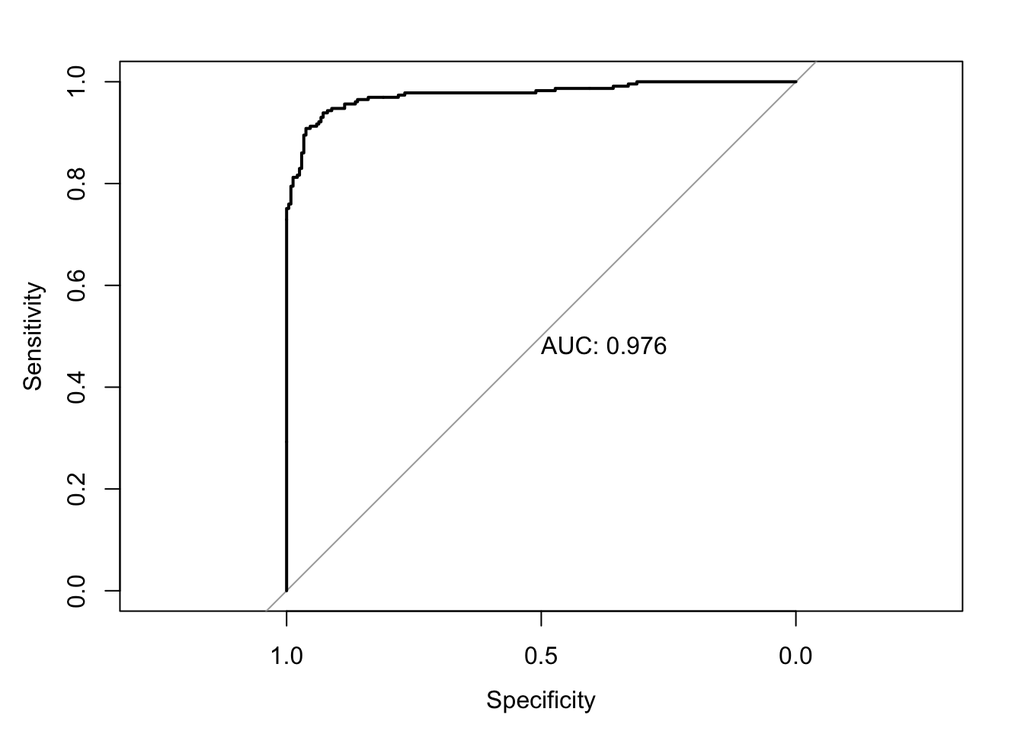

```r
mt1$df_info
```

| id | formula | res.deviance | null.deviance | aic | accuracy | sensitivity | specificity | precision |
| --- | --- | --- | --- | --- | --- | --- | --- | --- |
| mt1 | target ~ . + log(dis)+log(nox) | 176.193 | 645.876 | 200.193 | 0.931 | 0.913 | 0.949 | 0.946 |

```r
trans_models.df  <- rbind(trans_models.df, mt1$df_info)
```

We see that the transformed predictors that were introduced are collinear with the original predictors. To deal with this issue we remove the original predictors and proceed.

```r
car::vif(mt1$model)
```

```
        zn      indus        nox        age        dis        rad        tax
  1.935681   3.682769 793.082457   1.830976  45.039191   1.773397   2.181768
   ptratio       medv   log(dis)   log(nox)
  1.958810   2.605745  57.709494 743.376530
```

```r
mt2 <- build_model("mt2","target ~ . + log(dis)+log(nox)-dis-nox", data=data_train_trans)
```

```
Call:
glm(formula = formula, family = binomial, data = data)

Deviance Residuals:
    Min       1Q   Median       3Q      Max
-1.7852  -0.1535  -0.0023   0.0040   3.4072

Coefficients:
             Estimate Std. Error z value Pr(>|z|)
(Intercept) -1.635575   3.473533  -0.471 0.637735
zn          -0.045662   0.028819  -1.584 0.113098
indus       -0.007702   0.044940  -0.171 0.863930
age          0.035947   0.011302   3.181 0.001470 **
rad          0.682013   0.158560   4.301 1.70e-05 ***
tax         -0.005718   0.002838  -2.015 0.043929 *
ptratio      0.354516   0.112526   3.151 0.001630 **
medv         0.128618   0.037983   3.386 0.000709 ***
log(dis)     3.201847   0.875133   3.659 0.000254 ***
log(nox)    25.467685   3.985613   6.390 1.66e-10 ***
---
Signif. codes:  0 '***' 0.001 '**' 0.01 '*' 0.05 '.' 0.1 ' ' 1

(Dispersion parameter for binomial family taken to be 1)

    Null deviance: 645.88  on 465  degrees of freedom
Residual deviance: 193.11  on 456  degrees of freedom
AIC: 213.11

Number of Fisher Scoring iterations: 9
```

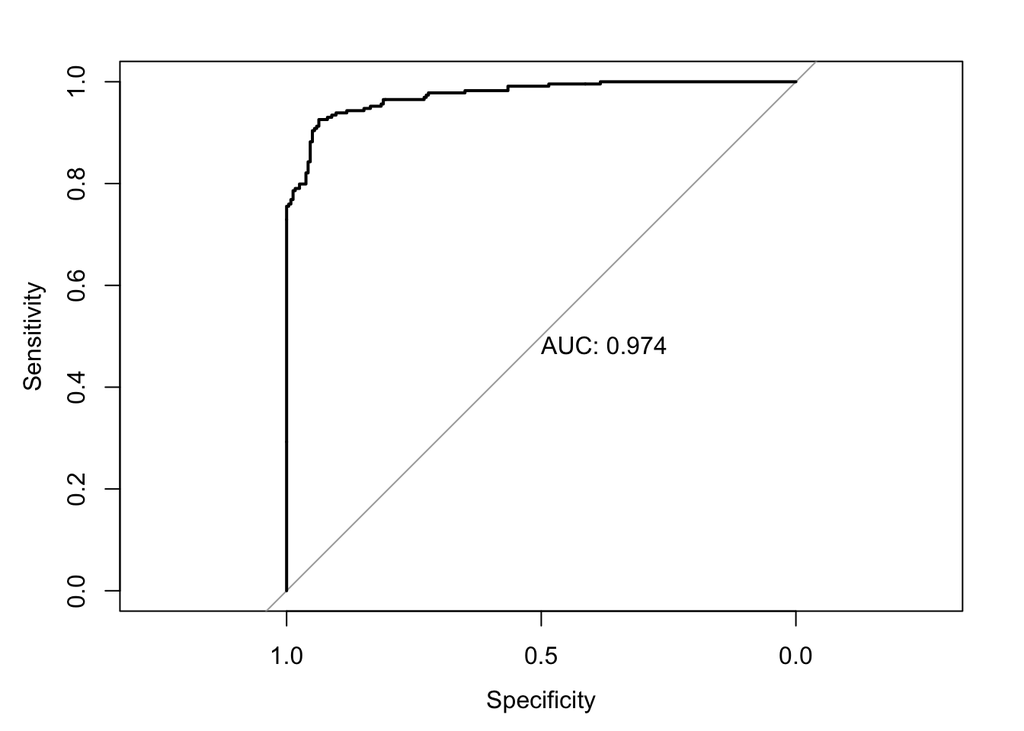

```r
mt2$df_info
```

| id | formula | res.deviance | null.deviance | aic | accuracy | sensitivity | specificity | precision |
| --- | --- | --- | --- | --- | --- | --- | --- | --- |
| mt2 | target ~ . + log(dis)+log(nox)-dis-nox | 193.108 | 645.876 | 213.108 | 0.931 | 0.926 | 0.937 | 0.934 |

```r
trans_models.df  <- rbind(trans_models.df, mt2$df_info)
```

```r
mt3 <- build_model("mt3","target ~ . + log(dis)+log(nox)-dis-nox-indus", data=data_train_trans)
```

```
Call:
glm(formula = formula, family = binomial, data = data)

Deviance Residuals:
    Min       1Q   Median       3Q      Max
-1.8024  -0.1526  -0.0022   0.0037   3.4053

Coefficients:
             Estimate Std. Error z value Pr(>|z|)
(Intercept) -1.850196   3.234215  -0.572 0.567275
zn          -0.045716   0.028709  -1.592 0.111298
age          0.035896   0.011292   3.179 0.001478 **
rad          0.689837   0.152274   4.530 5.89e-06 ***
tax         -0.005869   0.002686  -2.185 0.028890 *
ptratio      0.354632   0.112751   3.145 0.001659 **
medv         0.129441   0.037771   3.427 0.000610 ***
log(dis)     3.226553   0.864740   3.731 0.000191 ***
log(nox)    25.305601   3.862591   6.551 5.70e-11 ***
---
Signif. codes:  0 '***' 0.001 '**' 0.01 '*' 0.05 '.' 0.1 ' ' 1

(Dispersion parameter for binomial family taken to be 1)

    Null deviance: 645.88  on 465  degrees of freedom
Residual deviance: 193.14  on 457  degrees of freedom
AIC: 211.14

Number of Fisher Scoring iterations: 9
```

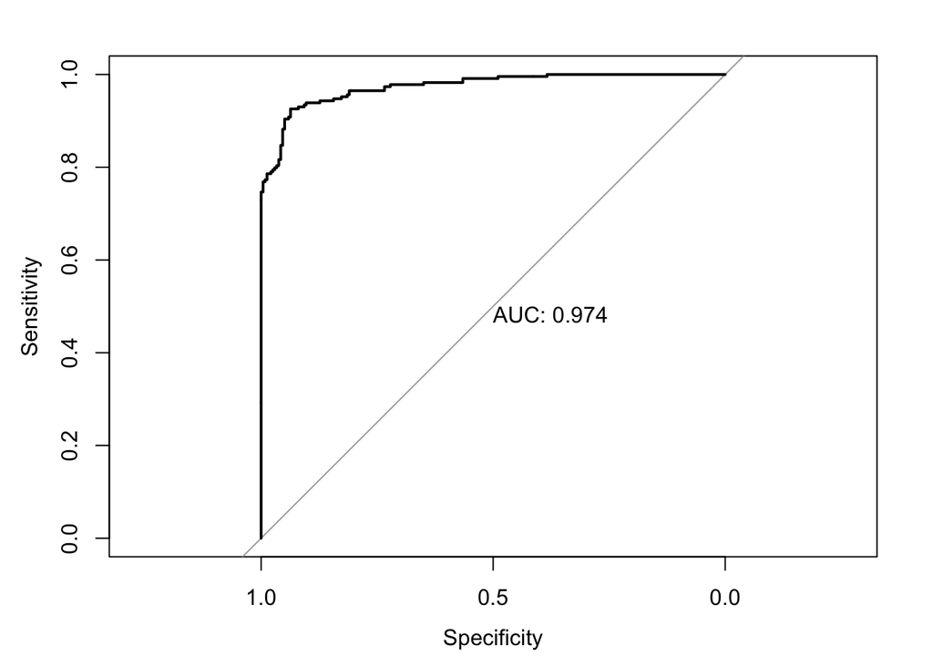

```r
mt3$df_info
```

| id | formula | res.deviance | null.deviance | aic | accuracy | sensitivity | specificity | precision |
| --- | --- | --- | --- | --- | --- | --- | --- | --- |
| mt3 | target ~ . + log(dis)+log(nox)-dis-nox-indus | 193.138 | 645.876 | 211.138 | 0.931 | 0.926 | 0.937 | 0.934 |

```r
trans_models.df  <- rbind(trans_models.df, mt3$df_info)
```

```r
mt4 <- build_model("mt4","target ~ . + log(dis)+log(nox)-dis-nox-indus-zn", data=data_train_trans)
```

```
Call:
glm(formula = formula, family = binomial, data = data)

Deviance Residuals:
    Min       1Q   Median       3Q      Max
-1.7287  -0.1640  -0.0074   0.0044   3.2107

Coefficients:
             Estimate Std. Error z value Pr(>|z|)
(Intercept) -1.873364   3.250243  -0.576 0.564361
age          0.036544   0.011193   3.265 0.001095 **
rad          0.675544   0.144596   4.672 2.98e-06 ***
tax         -0.006190   0.002579  -2.400 0.016407 *
ptratio      0.400345   0.109666   3.651 0.000262 ***
medv         0.123227   0.037168   3.315 0.000915 ***
log(dis)     2.931249   0.826099   3.548 0.000388 ***
log(nox)    25.875044   3.876728   6.674 2.48e-11 ***
---
Signif. codes:  0 '***' 0.001 '**' 0.01 '*' 0.05 '.' 0.1 ' ' 1

(Dispersion parameter for binomial family taken to be 1)

    Null deviance: 645.88  on 465  degrees of freedom
Residual deviance: 196.15  on 458  degrees of freedom
AIC: 212.15

Number of Fisher Scoring iterations: 9
```

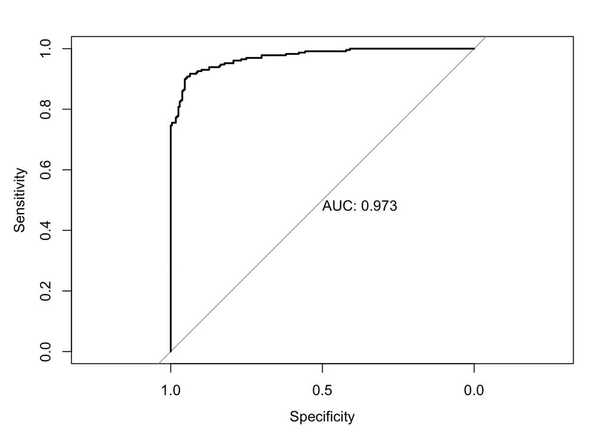

```r
mt4$df_info
```

| id | formula | res.deviance | null.deviance | aic | accuracy | sensitivity | specificity | precision |
| --- | --- | --- | --- | --- | --- | --- | --- | --- |
| mt4 | target ~ . + log(dis)+log(nox)-dis-nox-indus-zn | 196.153 | 645.876 | 212.153 | 0.925 | 0.913 | 0.937 | 0.933 |

```r
trans_models.df  <- rbind(trans_models.df, mt4$df_info)
```

## Model Selection

```r
models.df
```

| id | formula | res.deviance | null.deviance | aic | accuracy | sensitivity | specificity | precision |
| --- | --- | --- | --- | --- | --- | --- | --- | --- |
| m1 | target ~ . | 192.047 | 645.876 | 218.047 | 0.916 | 0.904 | 0.928 | 0.924 |
| m1_b | target ~ . -rm | 192.711 | 645.876 | 216.711 | 0.916 | 0.904 | 0.928 | 0.924 |
| m1_c | target ~ . -rm - chas | 194.244 | 645.876 | 216.244 | 0.923 | 0.913 | 0.932 | 0.929 |
| m1_d | target ~ . -rm -chas -indus | 195.515 | 645.876 | 215.515 | 0.912 | 0.908 | 0.916 | 0.912 |
| m1_e | target ~ . -rm -chas -indus -lstat | 197.323 | 645.876 | 215.323 | 0.912 | 0.904 | 0.920 | 0.916 |
| m2 | target ~ . | 169.950 | 643.025 | 193.950 | 0.927 | 0.916 | 0.937 | 0.933 |
| m2_b | target ~ . -rm - lstat | 171.780 | 643.025 | 191.780 | 0.927 | 0.916 | 0.937 | 0.933 |
| m2_c | target ~ . -rm -lstat -indus | 173.698 | 643.025 | 191.698 | 0.918 | 0.907 | 0.928 | 0.924 |

However, the models that used additional transformed features had different results compared to the observations above. This time, both residual deviance and AIC seem to increase with smaller models.

```r
trans_models.df
```

| id | formula | res.deviance | null.deviance | aic | accuracy | sensitivity | specificity | precision |
| --- | --- | --- | --- | --- | --- | --- | --- | --- |
| mt1 | target ~ . + log(dis)+log(nox) | 176.193 | 645.876 | 200.193 | 0.931 | 0.913 | 0.949 | 0.946 |
| mt2 | target ~ . + log(dis)+log(nox)-dis-nox | 193.108 | 645.876 | 213.108 | 0.931 | 0.926 | 0.937 | 0.934 |
| mt3 | target ~ . + log(dis)+log(nox)-dis-nox-indus | 193.138 | 645.876 | 211.138 | 0.931 | 0.926 | 0.937 | 0.934 |
| mt4 | target ~ . + log(dis)+log(nox)-dis-nox-indus-zn | 196.153 | 645.876 | 212.153 | 0.925 | 0.913 | 0.937 | 0.933 |

Our preference for this model is also confirmed by a likelyhood ratio test comparing mt1 (largest model) with mt4 (smaller model).

When comparing a larger to a smaller model, the null hypothesis is that the coefficients in the larger model are 0. In our case, the small p value suggests that the extra coefficients are not 0 and that we prefer the larger model.

```r
anova(mt4$model, mt1$model, test = "LRT")
```

|  | Resid. Df | Resid. Dev | Df | Deviance | Pr(>Chi) |
| --- | --- | --- | --- | --- | --- |
| 1 | 458 | 196.1534 | NA | NA | NA |
| 2 | 454 | 176.1926 | 4 | 19.96086 | 0.0005083631 |

```r
coefs <- as.data.frame(exp(mt1$model$coefficients))
coefs
```

|  | exp(mt1$model$coefficients) |
| --- | --- |
| (Intercept) | 1.899369e-150 |
| zn | 9.381339e-01 |
| indus | 1.002248e+00 |
| nox | 3.655439e+169 |
| age | 1.044859e+00 |
| dis | 5.153621e-02 |
| rad | 2.259466e+00 |
| tax | 9.932369e-01 |
| ptratio | 1.535511e+00 |
| medv | 1.134281e+00 |

[output cut: 2 more lines]

We can now interpret the marginal effects as follows. For example, with each unit increase in distance to employment centers neighborhoods are 17% less likely to be above the median crime rate. Note that the `nox` relative likelyhood is a very percentage, but this is due to the scale of the units. The nitrogen oxides concentrations are measured in part per million and unit change of 1 for this predictor is very large and an extrapolation beyond the domain of the `nox` variable. The effect is also modulated by the `log(nox)` variable which decreases its impact to some extent.

```r
# Marginal effects
LogitScalar <- mean(dlogis(predict(mt1$model, type="link")))
marg <- LogitScalar * coef(mt1$model)
marg <- as.data.frame(marg)
marg[] <- lapply(marg, function(x) sprintf("%.4f", x))
marg
```

|  | marg |
| --- | --- |
| (Intercept) | -20.2533 |
| zn | -0.0038 |
| indus | 0.0001 |
| nox | 22.9373 |
| age | 0.0026 |
| dis | -0.1742 |
| rad | 0.0479 |
| tax | -0.0004 |
| ptratio | 0.0252 |
| medv | 0.0074 |

[output cut: 2 more lines]

Looking at the marginal model plots, we see that the for all variables the data follows the expected values of the model, though there is a slight variation in the variables indus and age but not significant. We can therefore say that this is the correct model for the given data.

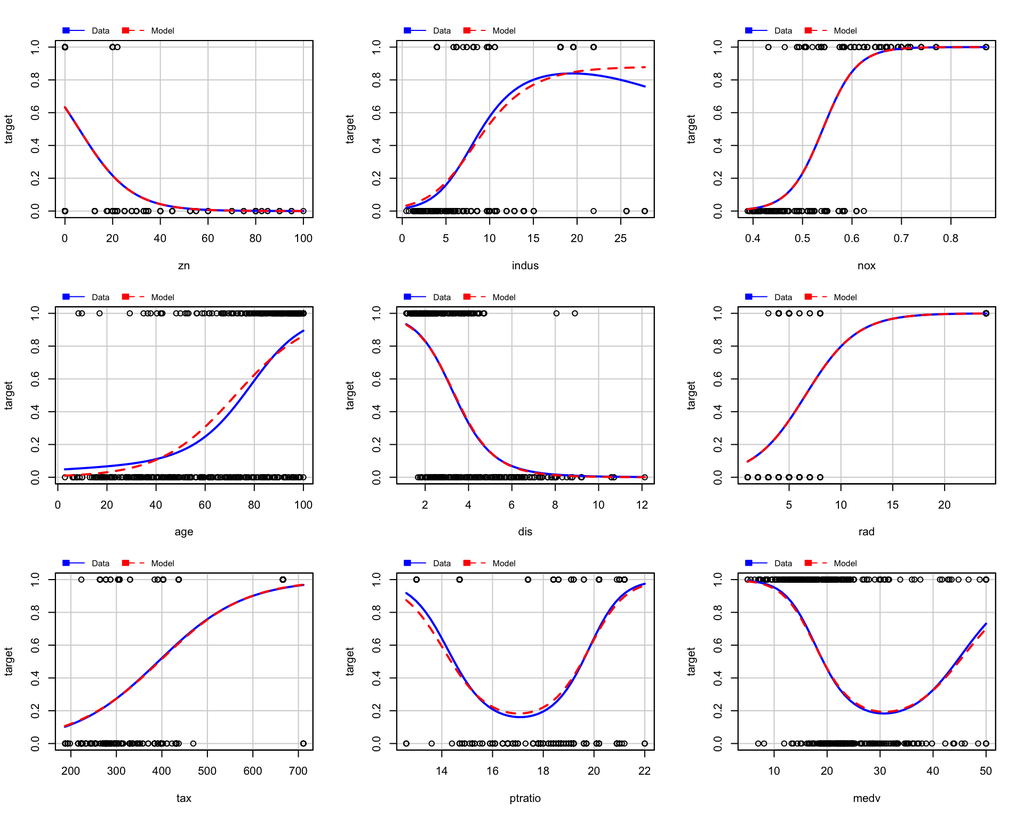

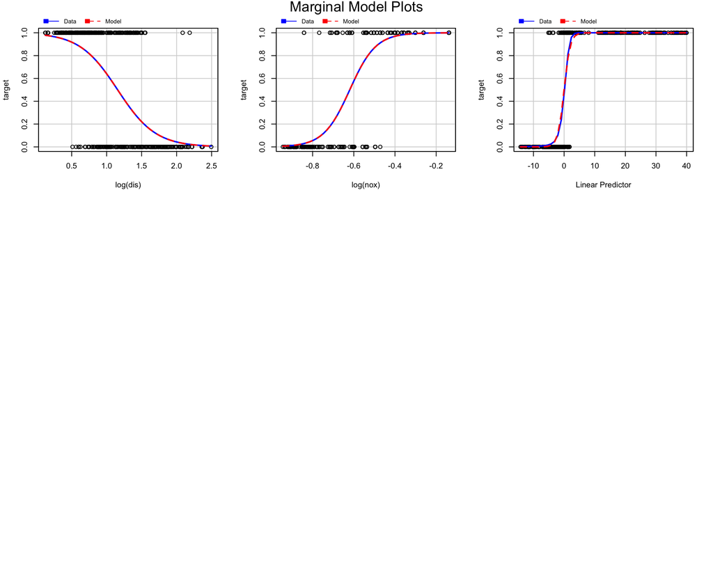

```r
marginalModelPlots(glm(target ~ . + log(dis)+log(nox), data=data_train_trans, family = binomial))
```

Based on model mt1, below is the prediction distribution of the test dataset, we see that the distribution is fairly split between the binary variable target

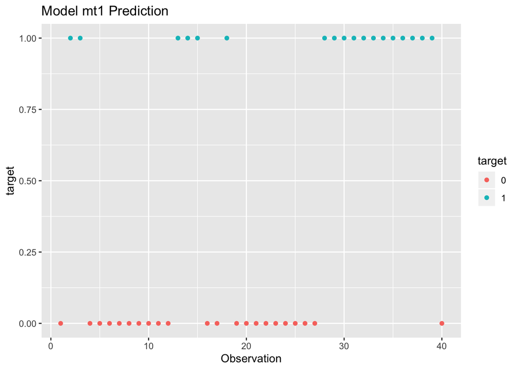

```r
data_test_trans <- data_test %>% select(-chas,-rm,-lstat)
test_predict <- predict(mt1$model, newdata=data_test_trans)
test_predict <- ifelse(test_predict<.5,0,1)

data_test$target <- test_predict

ggplot(data_test, aes(x=index(data_test), y=target, color=factor(target))) + geom_point() +
  labs(x="Observation", y="target", title = "Model mt1 Prediction", colour = "target")
```

```r
table(test_predict)
```

```
test_predict
 0  1
22 18
```

```r
write.csv(test_predict, "CrimePredictions.csv")
```